# 2021-10-20

# Existing wind measures

- BOM has wind data but need to contact them for the data:
  - http://www.bom.gov.au/climate/how/newproducts/IDChw.shtml
- CSIRO has near surface wind speed but it is interpolated data rather than observational
  - https://data.csiro.au/collections/collection/CIcsiro:Wind_Speed/DItrue
  - Confirm we are interested in observational data, not processed one.
- Global Historical Climatology Network (Daily) doesn’t have wind data for australian stations
- Integrated Surface Database (ISD) from NOAA has global hourly and synoptic surface observations.
  - https://www.ncei.noaa.gov/products/land-based-station/integrated-surface-database
  - In Victoria, there are 84 stations and I have compiled the 2019 - 2020 data for those stations.
- Could also look NASA power data - their website is under maintenance this wekeend

# Integrated Surface Database (ISD) from NOAA

*Metadata about this wind variable is in meta/isd-format-document.pdf*

- **wind direction**: angle measures in a clockwise direction, between true north and the direction from which the wind is blowing. MIN: 001 MAX: 360 UNITS: Angular Degrees
- **wind direction quality**: In the data only 1 and 9 present, which represent 1 = Passed all quality control check and 9 = Passed gross limits check if element is present
- **wind type**: type presented: N = Normal, V = Variable, C = Calm, and 9 = Missing. The missingness is ~5% for ~7 stations.
- **wind speed**: similar missing pattern as above. The rate of horizontal travel of air past a fixed point. MIN: 0000 MAX: 0900 UNITS: meters per second SCALING FACTOR: 10. Convert to kilometer per hour by VALUE / 10 * 3.6
- **wind speed quality**: In the data only 1 and 9 present, which represent 1 = Passed all quality control check and 9 = Passed gross limits check if element is present

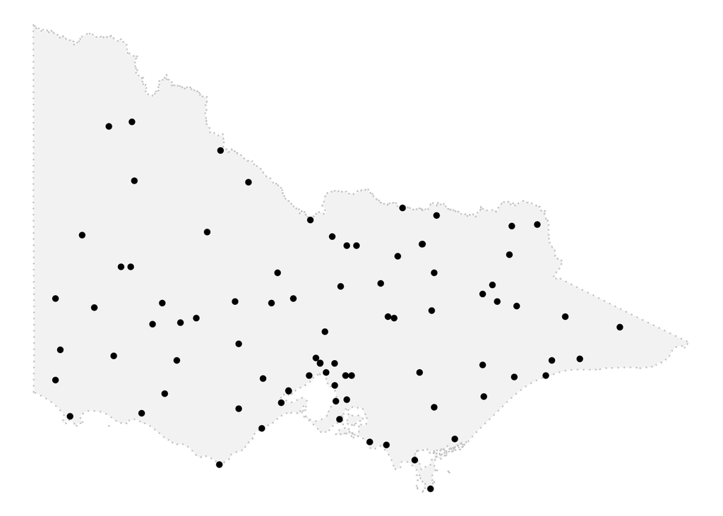

```
## # Cubble: time-wise: long form
## # Key:    usaf [84]
## # Leaves: usaf [fct], wban [fct], station_name [chr], lat [dbl], lon [dbl],
## #   elev_m [dbl]
##    usaf   date     time                wind_direction wind_speed
##    <fct>  <chr>    <dttm>                       <dbl>      <dbl>
##  1 945959 20190101 2019-01-01 00:00:00            360       9.36
##  2 945959 20190101 2019-01-01 01:00:00             60      13.0
##  3 945959 20190101 2019-01-01 02:00:00             20      11.2
##  4 945959 20190101 2019-01-01 03:00:00             30      11.2
##  5 945959 20190101 2019-01-01 04:00:00             10       7.56
##  6 945959 20190101 2019-01-01 05:00:00             40      13.0
##  7 945959 20190101 2019-01-01 06:00:00            320      14.8
##  8 945959 20190101 2019-01-01 07:00:00            210       9.36
##  9 945959 20190101 2019-01-01 08:00:00            260      14.8
## 10 945959 20190101 2019-01-01 09:00:00            250      13.0
## # … with 1,057,468 more rows
```